# Time Series Analysis of Ozone Layer Thickness

Harold Choi S3866530

4/7/2021

# 1. Introduction

Ozone is a gas that has the ability to reflect harmful ultraviolet (UV) rays from the sun. This ozone gas is present in the Earth’s atmosphere abundantly, enabling life to exists on Earth if not for this protective layer of gas.

# 2. Method

In this project Rstudio will be used to analyze the data, perform fitting operations to determine the best fitted model and running some diagnostic on the data of changes in the thickness of the ozone layer of the Earth over the years.

Further, we will be predicting the thickness of the ozone in the future and propose a set of ARIMA(p, d, q) model using model specification tools such as ACF, PACF, ECF, BIC.

In the dataset the single variable, ozone layer thickness is measured in Dobson units. A decrease in thickness is represented by a negative value while a increase in thickness is represented by a positive value. The data is collected annually from 1927 to 2016, a total of 90 observations.

```r
library(TSA)
library(stats)
library(readr)
library(forecast)
library(tseries)
```

# 3. Load the data

```r
ozone <- read.csv("C:/Users/Asus/Desktop/Time Series/Assignment/data1.csv", header=FALSE)
head(ozone)
```

```
##           V1
## 1  1.3511844
## 2  0.7605324
## 3 -1.2685573
## 4 -1.4636872
## 5 -0.9792030
## 6  1.5085675
```

# 4. Analysis of Model

## 4.1 Convert the data to time series

```r
rownames(ozone) <- seq(from=1927, to=2016)
colnames(ozone) <- "Changes in thickness of ozone layer"
ozone <- ts(as.vector(ozone), start=1927, end = 2016, frequency=1)
class(ozone)
```

```
## [1] "ts"
```

## 4.2 Analysis of Ozone

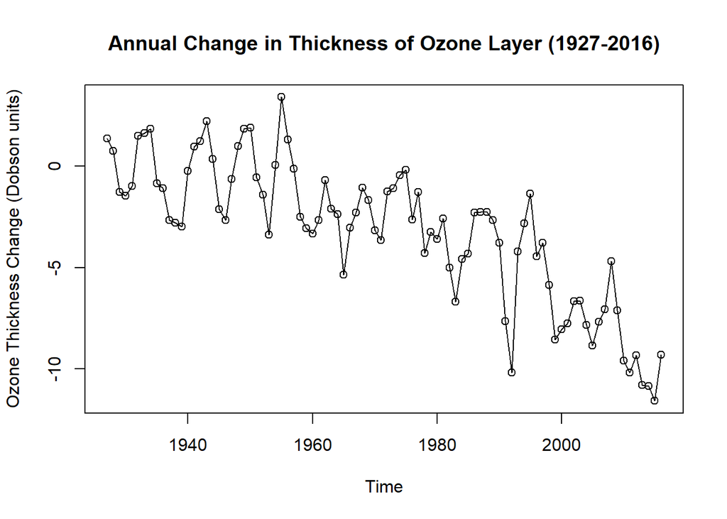

```r
plot(ozone, type="o", main="Annual Change in Thickness of Ozone Layer (1927-2016)", ylab="Ozone Thickness Change (Dobson units)")
```

From the plot above, there is a downward (negative) trend with no visible evidence of seasonality but minor areas of changing variance in the 1960s and 2000s. The time series display a moving average (MA) behaviour at the start and autoregressive (AR) behviour towards the second half of the series. Lastly, there are no visible intervention or change point.

Based on the plot, the mean and variance are both not constant and the time series is not stationary. In addition, the trend is stochastic as the time series is not a function of time.

### 4.2a Scatter Plot

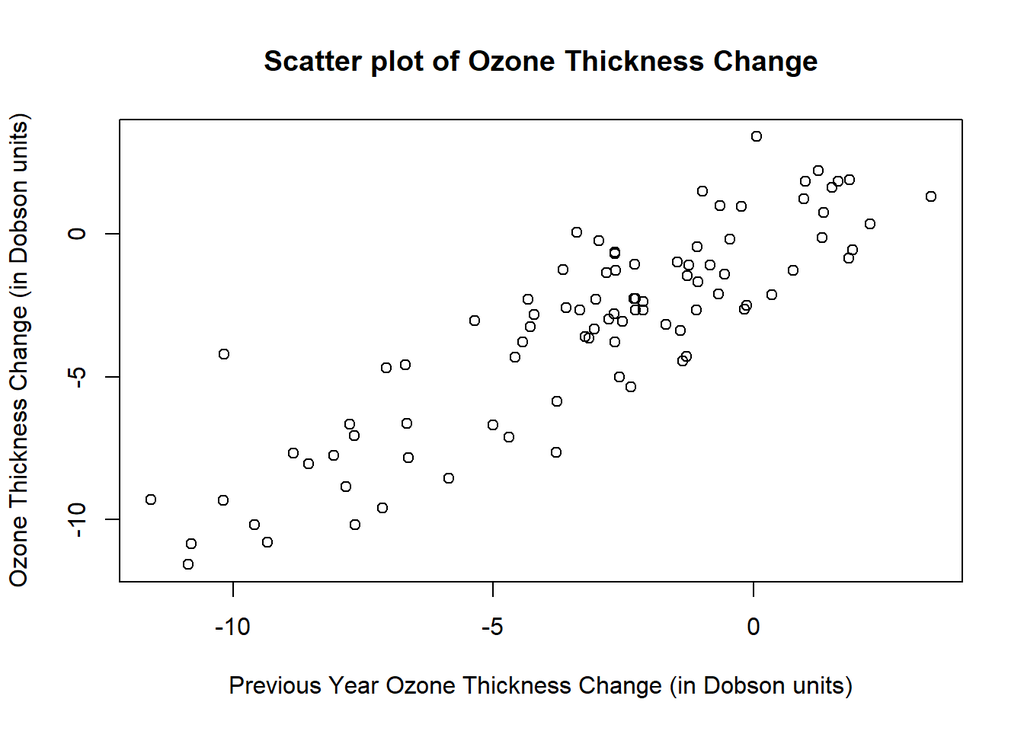

```r
plot(y=ozone,x=zlag(ozone),ylab='Ozone Thickness Change (in Dobson units)', xlab='Previous Year Ozone Thickness Change (in Dobson units)' , main = 'Scatter plot of Ozone Thickness Change')
```

The scatter plot shows a upward trends similar to the time series plot with many points very close to each other or otherwise overlapping. Therefore there is high correlation between the change in ozone thickness of consecutive years.

### 4.2b Correlation

```r
y= ozone
x=zlag(ozone)
index = 2:length(x)
cor(y[index], x[index])
```

```
## [1] 0.8700381
```

In calculating the correlation coefficient is 0.87 for the ozone thickness change and previous year ozone thickness change. Therefore the ozone time series is highly autocorrelated due to the existence of succeeding time points.

### 4.2c ACF and PACF

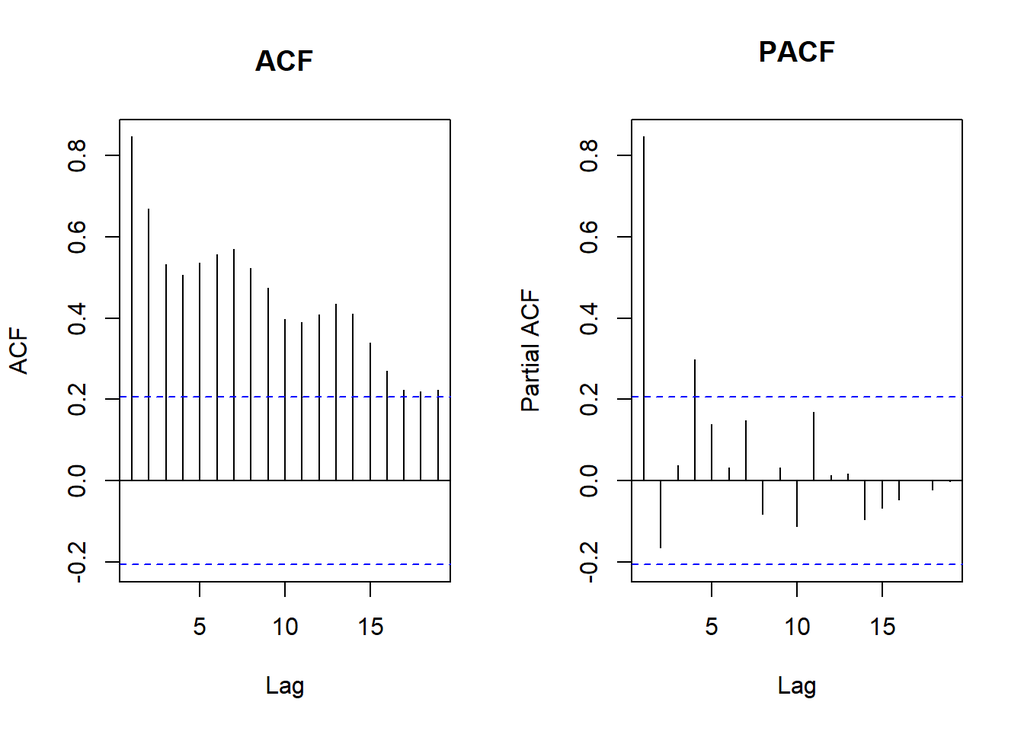

```r
par(mfrow=c(1,2))
acf(ozone, main='ACF')
pacf(ozone, main='PACF')
```

The ACF indicates a slow decaying pattern with signs of seasonality. While the PACF, the first lag is indicates very high autocorrelation implying the existence of a trend and non-stationarity.

## 4.3 Fitting the Linear Model

```r
linear_model <- lm(ozone ~ time(ozone))
summary(linear_model)
```

```
##
## Call:
## lm(formula = ozone ~ time(ozone))
##
## Residuals:
##     Min      1Q  Median      3Q     Max
## -4.7165 -1.6687  0.0275  1.4726  4.7940
##
## Coefficients:
##               Estimate Std. Error t value Pr(>|t|)
## (Intercept) 213.720155  16.257158   13.15   <2e-16 ***
## time(ozone)  -0.110029   0.008245  -13.34   <2e-16 ***
## ---
## Signif. codes:  0 '***' 0.001 '**' 0.01 '*' 0.05 '.' 0.1 ' ' 1
##
## Residual standard error: 2.032 on 88 degrees of freedom
## Multiple R-squared:  0.6693, Adjusted R-squared:  0.6655
## F-statistic: 178.1 on 1 and 88 DF,  p-value: < 2.2e-16
```

The R-squared is 0.6693 and adjusted R-squared is 0.6655 which means that 66.55% of the variation in ozone thickness data series is explained by linear model. The adjusted R-squared is partially significant as it is less than 0.7.

The p-value of the coefficient of the intercept and independent variable is extremely small and the null hypothesis is rejected making them statistically significant. Therefore the coefficient is significant and is likely to be a useful in the model.

The p-value of the model is also very small which means that the linear model as a whole is able to explain the time series, ozone.

### 4.3a Ozone time series with linear model trend line

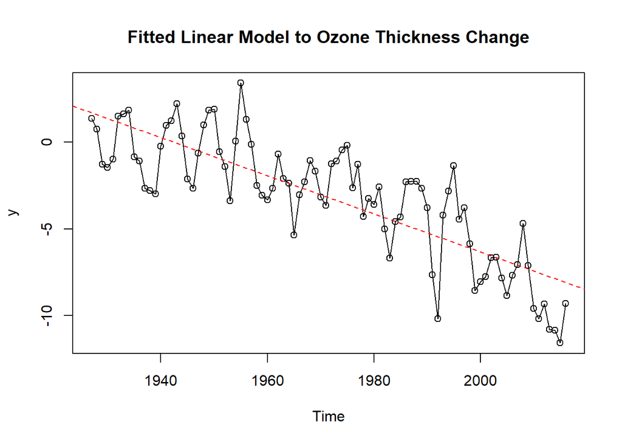

```r
plot(ozone, type="o", main='Fitted Linear Model to Ozone Thickness Change', ylab="y")
abline(linear_model, col="red", lty=2)
```

From the trend line plotted over the ozone time series, the line does not capture the series very well. To further investigate, the residuals will be analyzed.

## 4.4 Residual Analysis of Linear Model

```r
res.linear_model <- rstudent(linear_model)
```

### 4.4a Time Series plot of Standardized Residuals

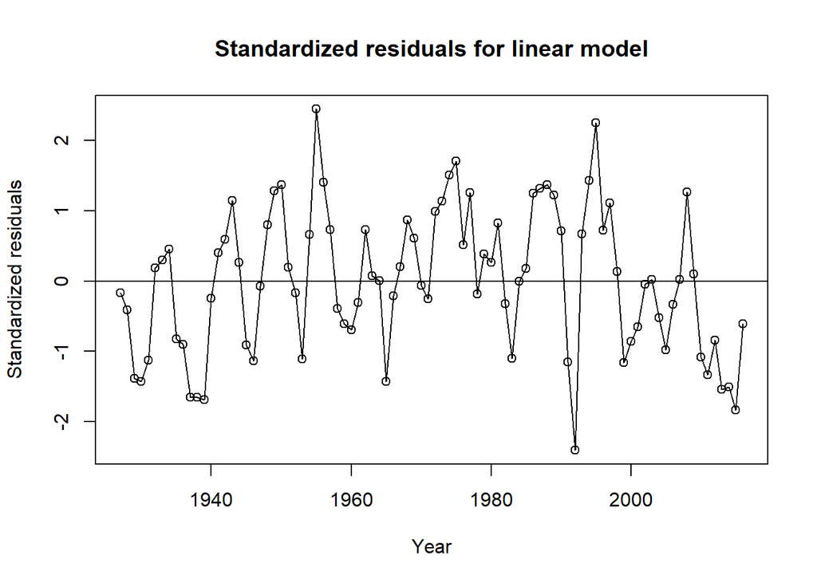

```r
plot(res.linear_model, x=as.vector(time(ozone)), type="o", xlab="Year", ylab="Standardized residuals", main="Standardized residuals for linear model")
abline(h=0)
```

For the time series plot of standardized residuals, there should be a totally random pattern in the time series. The downward trend of the original data series has improved through the linear model showing less signs of trend.

### 4.4b Histogram

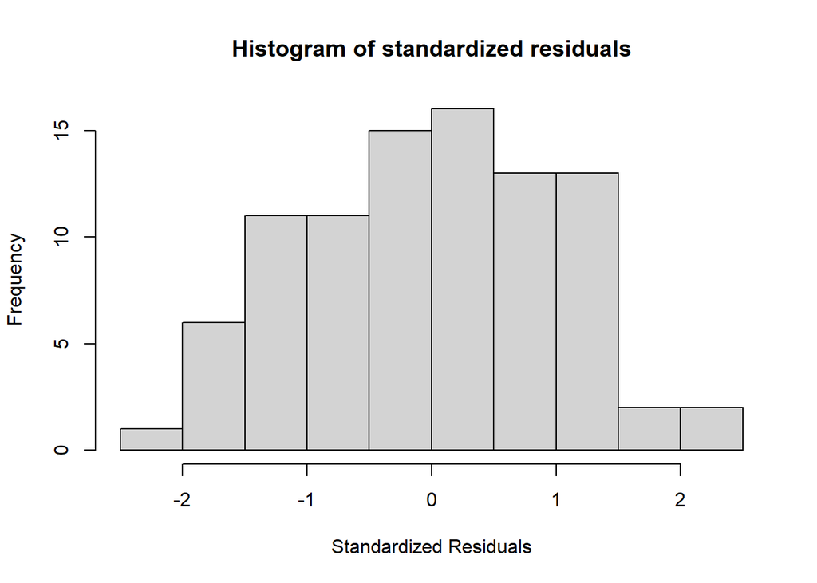

```r
hist(res.linear_model, main="Histogram of standardized residuals", xlab="Standardized Residuals")
```

The normality of residuals are explained in the histogram of the standardized residuals of the linear model which look partially symmetric with some exception on both edges.

### 4.4c Q-Q plot

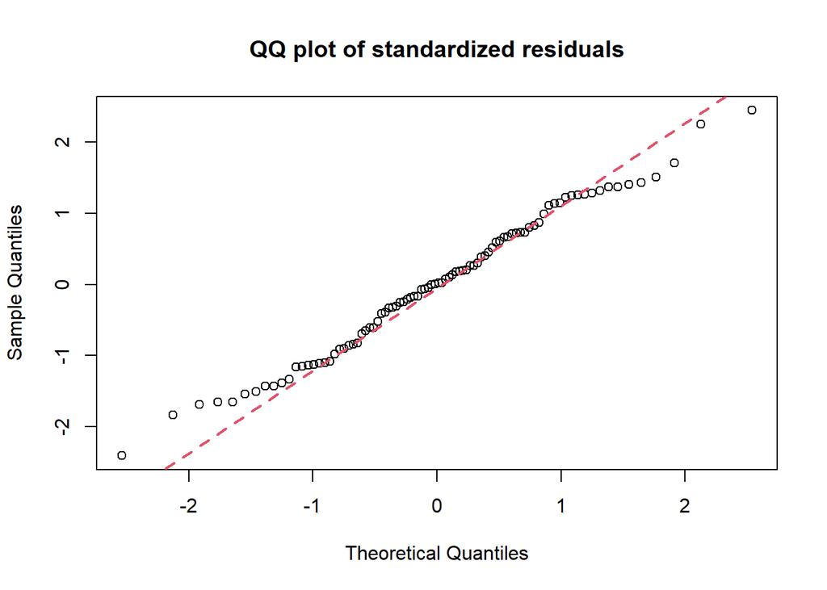

```r
qqnorm(res.linear_model, main="QQ plot of standardized residuals")
qqline(res.linear_model, col=2, lty=2, lwd=2)
```

The points at the start and end are not on the reference line indicating that the model is not the most ideal.

### 4.4d Shapiro-Wilks Normality Test

```r
shapiro.test(res.linear_model)
```

```
##
##  Shapiro-Wilk normality test
##
## data:  res.linear_model
## W = 0.98733, p-value = 0.5372
```

Shapiro-wilk normality test gives a p-value of 0.5372 which indicates the failure to reject the null hypothesis of that the stochastic component of the series is normally distribution.

### 4.4e ACF and PACF of standardized residuals

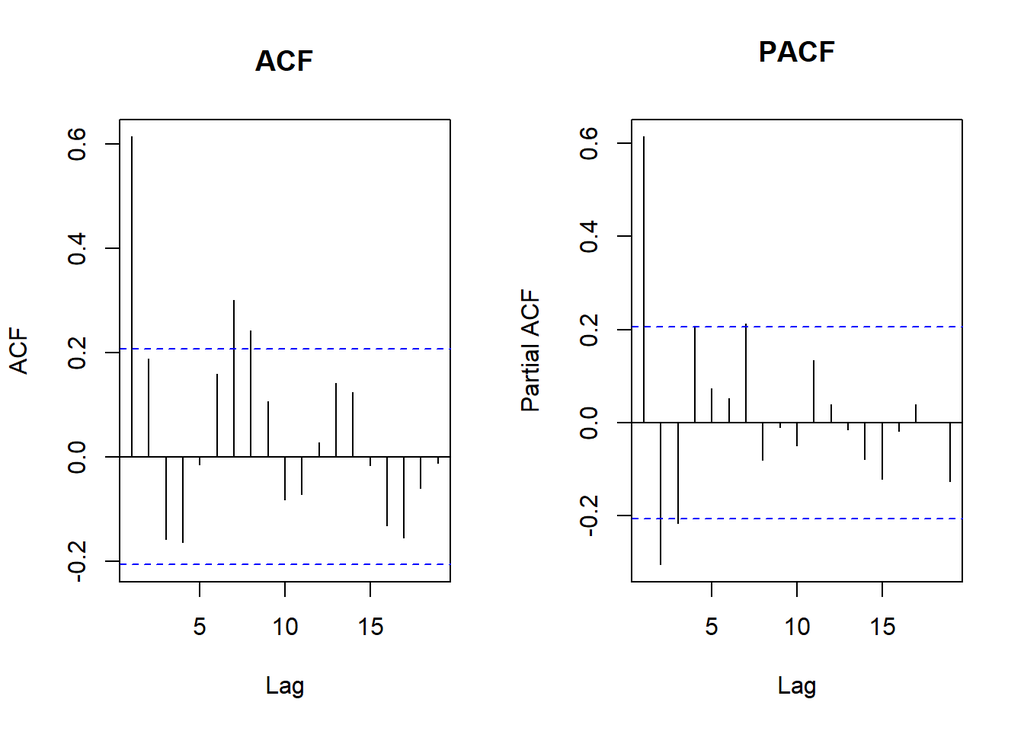

```r
par(mfrow=c(1,2))
acf(res.linear_model, main="ACF")
pacf(res.linear_model, main="PACF")
```

For ACF and PACF plot of standardized residuals, bars that are under the horizontal blue line are ideal as this indicates that there is no autocorrelation and the model could be a good fit. In this case the ACF shows 3 lags are above the blue horizontal dashed lines and PACF shows 5. Therefore the autocorrelation of the linear model is reduced when fitted with the linear model and stochastic component of the series is not white noise.

## 4.5 Fitting the Quadratic Model

```r
t = time(ozone)
t2 = t^2
quadratic_model <- lm(ozone ~ t + t2)
summary(quadratic_model)
```

```
##
## Call:
## lm(formula = ozone ~ t + t2)
##
## Residuals:
##     Min      1Q  Median      3Q     Max
## -5.1062 -1.2846 -0.0055  1.3379  4.2325
##
## Coefficients:
##               Estimate Std. Error t value Pr(>|t|)
## (Intercept) -5.733e+03  1.232e+03  -4.654 1.16e-05 ***
## t            5.924e+00  1.250e+00   4.739 8.30e-06 ***
## t2          -1.530e-03  3.170e-04  -4.827 5.87e-06 ***
## ---
## Signif. codes:  0 '***' 0.001 '**' 0.01 '*' 0.05 '.' 0.1 ' ' 1
##
## Residual standard error: 1.815 on 87 degrees of freedom
## Multiple R-squared:  0.7391, Adjusted R-squared:  0.7331
## F-statistic: 123.3 on 2 and 87 DF,  p-value: < 2.2e-16
```

For the quadratic model the R-squared is 0.7391 and adjusted R-squared is 0.7331 which is higher than the linear model. This means that 73.31% of the variation in the ozone thickness time series is explained by the quadratic trend which indicates that quadratic model is more significant and a better fit than the linear model that has only 66%.

The p-value of the coefficient of the intercept and independent variables are statiscally significant. Therefore the coefficient is likely to be a meaningful addition in the model.

The p-value of the model is also very small which means that the quadratic model as a whole is able to explain the time series, ozone.

Comparing we fitted quadratic line, the quadratic model looks to be a better fit than the linear model. Therefore the squared of time does contribute and improve the predicting power of the model from 0.6655 of linear model to 0.7331 of the quadratic model.

### 4.5a Ozone time series with quadratic model trend line

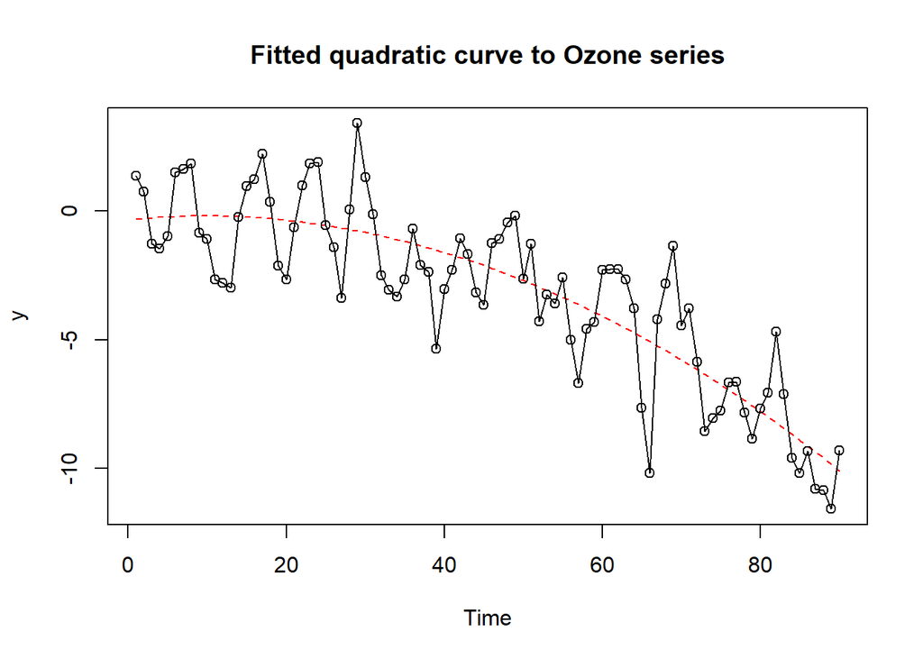

```r
plot(ts(fitted(quadratic_model)), main="Fitted quadratic curve to Ozone series", ylab="y",
     ylim = c(min(c(fitted(quadratic_model), as.vector(ozone))) ,
              max(c(fitted(quadratic_model), as.vector(ozone)))),
     lty=2, col="red")
lines(as.vector(ozone), type="o")
```

From the trend line plotted over the ozone time series, the line better capture the series compared to the linear model. To further investigate, the residuals will be analyzed.

## 4.6 Residual Analysis of Quadratic Model

```r
res.quadratic_model <- rstudent(quadratic_model)
```

### 4.6a Time Series plot of standardized residuals

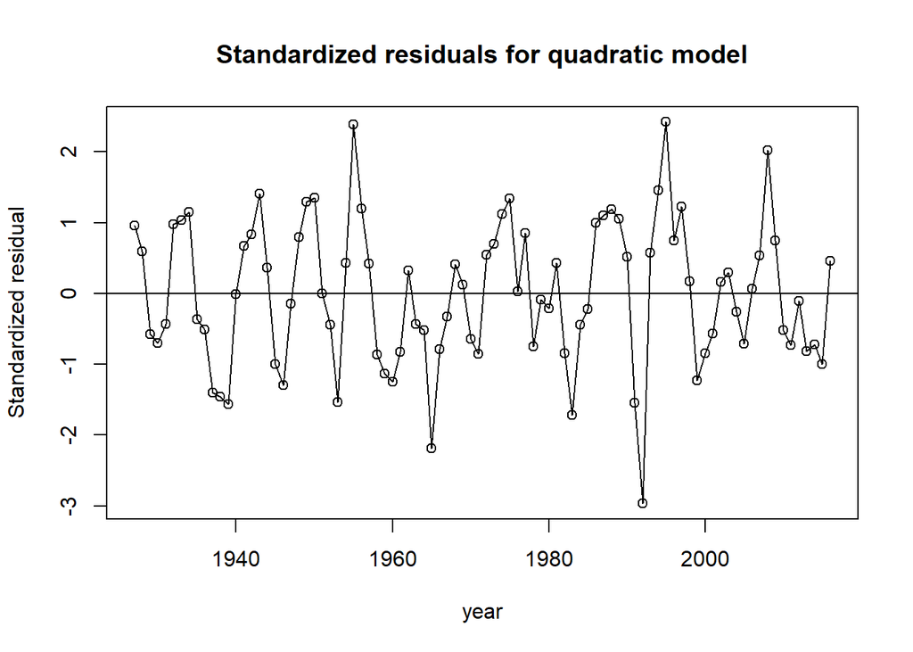

```r
plot(res.quadratic_model, x=as.vector(time(ozone)), type="o", xlab="year", ylab="Standardized residual", main="Standardized residuals for quadratic model")
abline(h=0)
```

The points are fluctuating around the line and the series looks similar to white noise as the pattern is relatively random.

### 4.6b Histogram

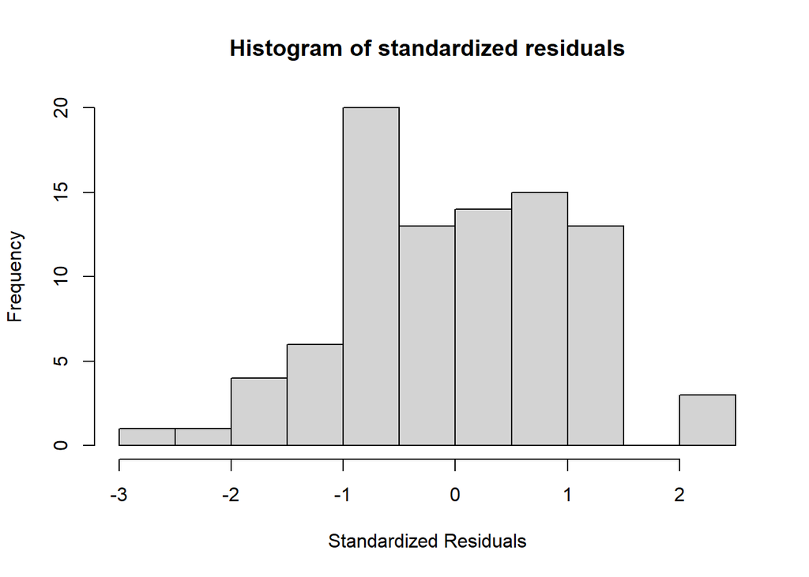

```r
hist(res.quadratic_model, main="Histogram of standardized residuals", xlab="Standardized Residuals")
```

The histogram of the standardized residuals of the quadratic model looks better than the linear model with some assymmetric toward the edge.

### 4.6c Q-Q plot

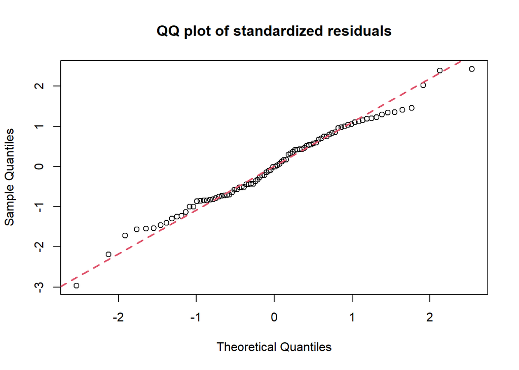

```r
qqnorm(res.quadratic_model, main="QQ plot of standardized residuals")
qqline(res.quadratic_model, col=2, lty=2, lwd=2)
```

The points at the start and end are not on the reference line making it diffcult to judge if the quadratic model is better than the linear model.

### 4.6d Shapiro-Wilks Normality Test

```r
shapiro.test(res.quadratic_model)
```

```
##
##  Shapiro-Wilk normality test
##
## data:  res.quadratic_model
## W = 0.98889, p-value = 0.6493
```

Shapiro-wilk normality test gives a p-value of 0.6493 which indicates the failure to reject the null hypothesis that the stochastic component of the quadratic model is normally distributed. In addition, the p-value of 0.6493 is higher than the linear model of 0.5372 which shows greater evidence for normality.

### 4.6e ACF and PACF of standardized residuals

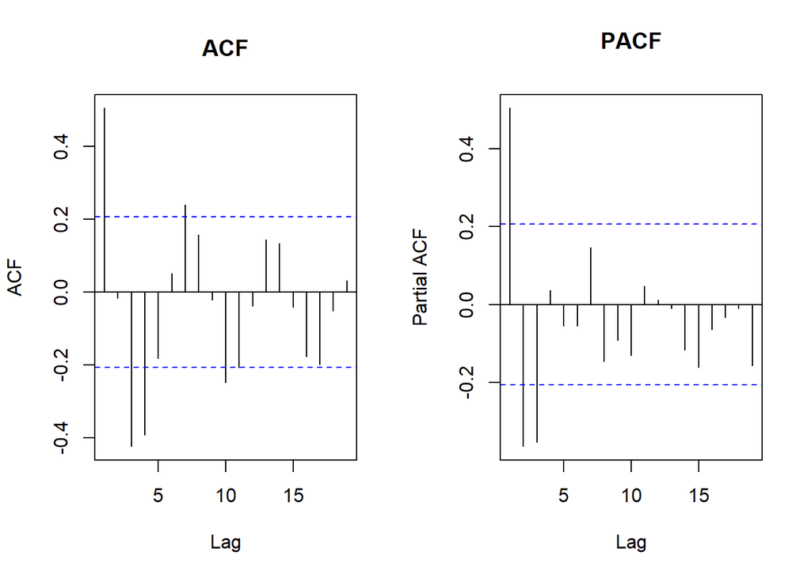

```r
par(mfrow=c(1,2))
acf(res.quadratic_model, main="ACF")
pacf(res.quadratic_model, main="PACF")
```

The ACF shows 5 lags are above the blue horizontal dashed lines indicating strong evidence for autocorrelation and PACF shows 3. The quadratic model ACF shows there is still autocorrelation but that has been reduced from the original data.

## 4.7 Fitting the Seasonal Model

Since there is a slight repetitive pattern noted in the time series plot from the ACF plot. The next model will be a seasonal/cyclical trend model. The assumption made will be that the pattern happens every 6 years.

[figure not shown]

```r
seasonal_data = ts(as.vector(matrix(ozone, nrow = 15, ncol = 6)), frequency = 6)
plot(seasonal_data, type = 'o', main="Fitted quadratic curve to Ozone series", ylab="Ozone Thickness Change (Dobson units)" )
```

```r
season = season(seasonal_data)
seasonal_model = lm(seasonal_data~season-1)
summary(seasonal_model)
```

```
##
## Call:
## lm(formula = seasonal_data ~ season - 1)
##
## Residuals:
##     Min      1Q  Median      3Q     Max
## -8.4755 -1.6640  0.5134  2.3864  6.5111
##
## Coefficients:
##                Estimate Std. Error t value Pr(>|t|)
## seasonSeason-1  -2.8943     0.9318  -3.106 0.002585 **
## seasonSeason-2  -3.1722     0.9318  -3.404 0.001019 **
## seasonSeason-3  -3.6586     0.9318  -3.926 0.000176 ***
## seasonSeason-4  -3.1478     0.9318  -3.378 0.001108 **
## seasonSeason-5  -3.1039     0.9318  -3.331 0.001287 **
## seasonSeason-6  -3.2367     0.9318  -3.474 0.000814 ***
## ---
## Signif. codes:  0 '***' 0.001 '**' 0.01 '*' 0.05 '.' 0.1 ' ' 1
##
## Residual standard error: 3.609 on 84 degrees of freedom
## Multiple R-squared:  0.4589, Adjusted R-squared:  0.4202
## F-statistic: 11.87 on 6 and 84 DF,  p-value: 1.325e-09
```

The seasonal model R-squared is 0.4589 and adjusted R-squared is 0.4202 which is much lower than the linear and quadratic model.

The small p-value of the coefficents indicates that six coefficient are all statistically significant and is likely to be a meaningful addition in the model.

### 4.7a Ozone time series with seasonal model trend line

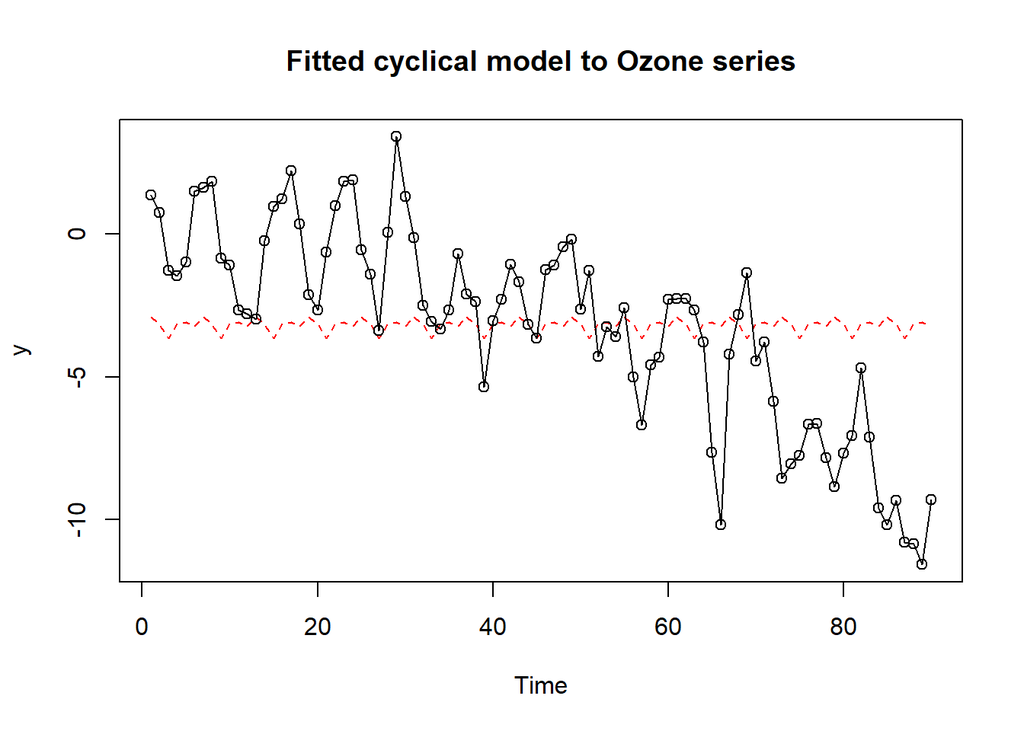

```r
plot(ts(fitted(seasonal_model)), ylab='y', main="Fitted cyclical model to Ozone series",
     ylim=c(min(c(fitted(seasonal_model), as.vector(seasonal_data))),
              max(c(fitted(seasonal_model), as.vector(seasonal_data)))),
     lty=2, col="red")
lines(as.vector(seasonal_data), type='o')
```

By plotting the seasonal model against the original plot, there is no trend and the seasonal model does not capture the data well.

## 4.8 Fitting the combined Seasonal and Quadratic Model

Next, the seasonal and quadratic model are combined and fitted to the observations.

```r
t = time(seasonal_data)
t2 = t^2
seasonal_quad_model = lm(seasonal_data~season+t+t2-1)
summary(seasonal_quad_model)
```

```
##
## Call:
## lm(formula = seasonal_data ~ season + t + t2 - 1)
##
## Residuals:
##     Min      1Q  Median      3Q     Max
## -5.3458 -1.3076  0.0912  1.3598  4.7563
##
## Coefficients:
##                Estimate Std. Error t value Pr(>|t|)
## seasonSeason-1 -0.46232    0.85049  -0.544    0.588
## seasonSeason-2 -0.63599    0.85462  -0.744    0.459
## seasonSeason-3 -1.01500    0.85834  -1.183    0.240
## seasonSeason-4 -0.39389    0.86166  -0.457    0.649
## seasonSeason-5 -0.23650    0.86458  -0.274    0.785
## seasonSeason-6 -0.25280    0.86710  -0.292    0.771
## t               0.26561    0.20079   1.323    0.190
## t2             -0.05512    0.01162  -4.742 8.79e-06 ***
## ---
## Signif. codes:  0 '***' 0.001 '**' 0.01 '*' 0.05 '.' 0.1 ' ' 1
##
## Residual standard error: 1.849 on 82 degrees of freedom
## Multiple R-squared:  0.8614, Adjusted R-squared:  0.8479
## F-statistic:  63.7 on 8 and 82 DF,  p-value: < 2.2e-16
```

The combined seasonal & quadratic model R-squared is 0.8614 and adjusted R-squared is 0.8479 which is highest among the linear, quadratic, and seasonal model.

However, the large p-value for the 6 seasonal coefficient and the first time series coefficient indicates that they are unlikely statistically significant.

### 4.8a Ozone time series with combined seasonal & quadratic model trend line

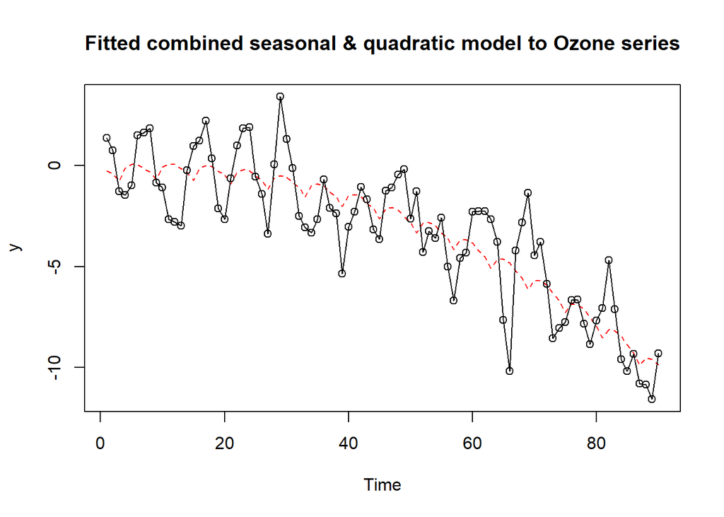

```r
plot(ts(fitted(seasonal_quad_model)),ylab='y', main = "Fitted combined seasonal & quadratic model to Ozone series",
     ylim=c(min(c(fitted(seasonal_quad_model), as.vector(seasonal_data))),
            max(c(fitted(seasonal_quad_model), as.vector(seasonal_data)))),
     lty=2, col="red")
lines(as.vector(seasonal_data), type = 'o')
```

The combination model lines looks like a better fit than seasonal model.

## 4.9 Residual Analysis of combined Seasonal & Quadratic Model

```r
res.seasonal_quad_model <- rstudent(seasonal_quad_model)
```

### 4.9a Time Series plot of standardized residuals

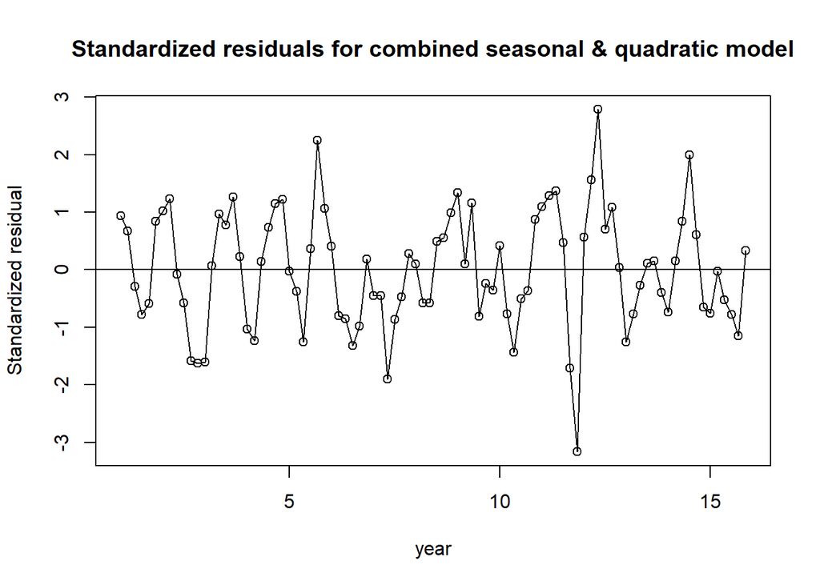

```r
plot(res.seasonal_quad_model, x=as.vector(time(seasonal_data)), type="o", xlab="year", ylab="Standardized residual", main="Standardized residuals for combined seasonal & quadratic model")
abline(h=0)
```

### 4.9b Histogram

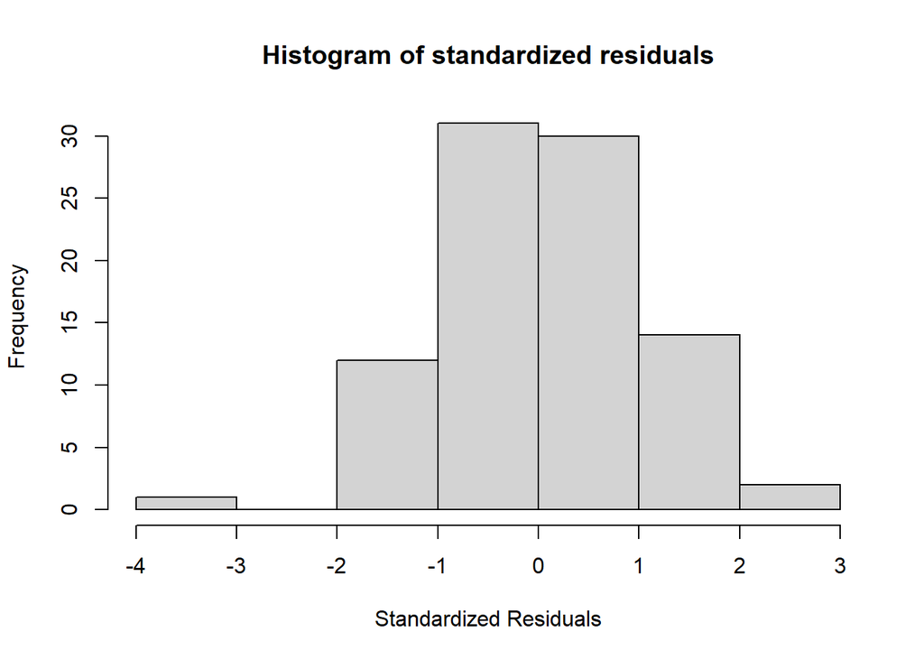

```r
hist(res.seasonal_quad_model, main="Histogram of standardized residuals", xlab="Standardized Residuals")
```

The histogram of the combined seasonal and quadratic model looks normal.

### 4.9c Q-Q Plot

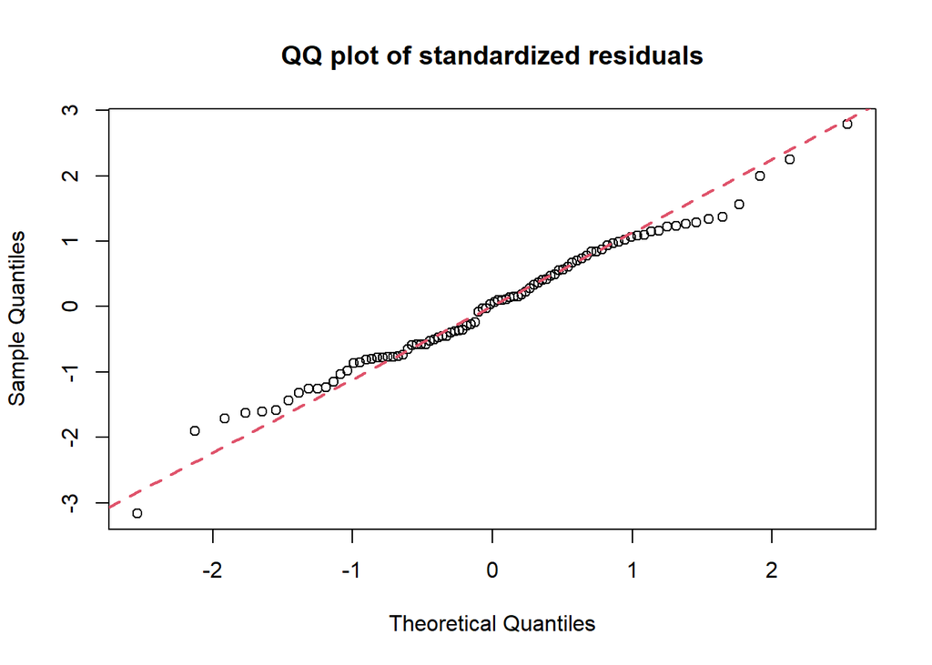

```r
qqnorm(res.seasonal_quad_model, main="QQ plot of standardized residuals")
qqline(res.seasonal_quad_model, col=2, lty=2, lwd=2)
```

The points in the qqplot shows signs of normal distribution as well.

### 4.9d Shapiro-Wilks Normality Test

```r
shapiro.test(res.seasonal_quad_model)
```

```
##
##  Shapiro-Wilk normality test
##
## data:  res.seasonal_quad_model
## W = 0.98964, p-value = 0.705
```

Shapiro-wilk normality test gives a p-value of 0.705, the null hypothesis that the stochastic component of the combined seasonal and quadratic model is not rejected.

### 4.9e ACF and PACF of standardized residuals

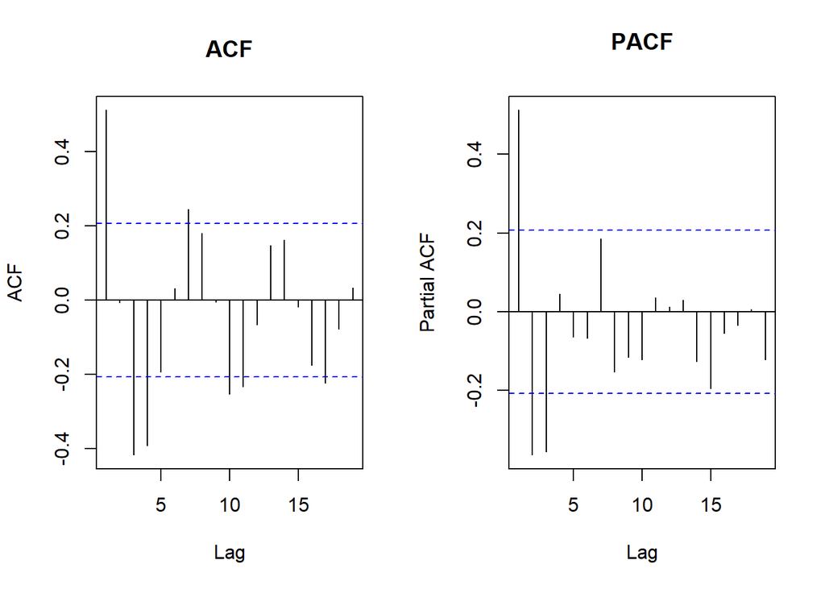

```r
par(mfrow=c(1,2))
acf(res.seasonal_quad_model, main="ACF")
pacf(res.seasonal_quad_model, main="PACF")
```

## 4.10 Fitting the Cosine Model

```r
har. <- harmonic(seasonal_data,1)
t <- time(seasonal_data)
t2 <- t^2
cosine_model <- lm(seasonal_data ~ har. + t+t2)
summary(cosine_model)
```

```
##
## Call:
## lm(formula = seasonal_data ~ har. + t + t2)
##
## Residuals:
##     Min      1Q  Median      3Q     Max
## -5.4075 -1.2271  0.0685  1.3942  4.5511
##
## Coefficients:
##                 Estimate Std. Error t value Pr(>|t|)
## (Intercept)     -0.49707    0.72907  -0.682    0.497
## har.cos(2*pi*t)  0.03759    0.27139   0.139    0.890
## har.sin(2*pi*t) -0.33543    0.27159  -1.235    0.220
## t                0.26535    0.19766   1.342    0.183
## t2              -0.05513    0.01144  -4.818 6.27e-06 ***
## ---
## Signif. codes:  0 '***' 0.001 '**' 0.01 '*' 0.05 '.' 0.1 ' ' 1
##
## Residual standard error: 1.82 on 85 degrees of freedom
## Multiple R-squared:  0.7438, Adjusted R-squared:  0.7317
## F-statistic: 61.69 on 4 and 85 DF,  p-value: < 2.2e-16
```

### 4.10a Ozone time series with cosine model trend line

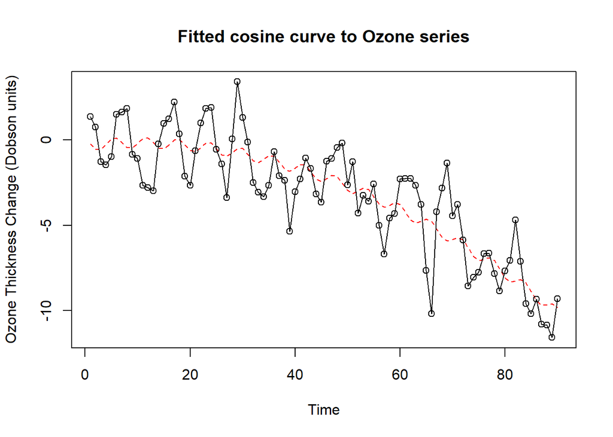

```r
plot(ts(fitted(cosine_model)), ylim=c(min(c(fitted(cosine_model), as.vector(seasonal_data))),
                                        max(c(fitted(cosine_model), as.vector(seasonal_data)))),
     ylab='Ozone Thickness Change (Dobson units)', main = "Fitted cosine curve to Ozone series", type="l",lty=2,col="red")
lines(as.vector(seasonal_data),type="o")
```

Based on the cosine model, thee trend line fits the data and the model looks significant.

## 4.11 Residual Analysis of Cosine Model

```r
res.cosine_model <- rstudent(cosine_model)
```

### 4.11a Time series plot of standardized residuals

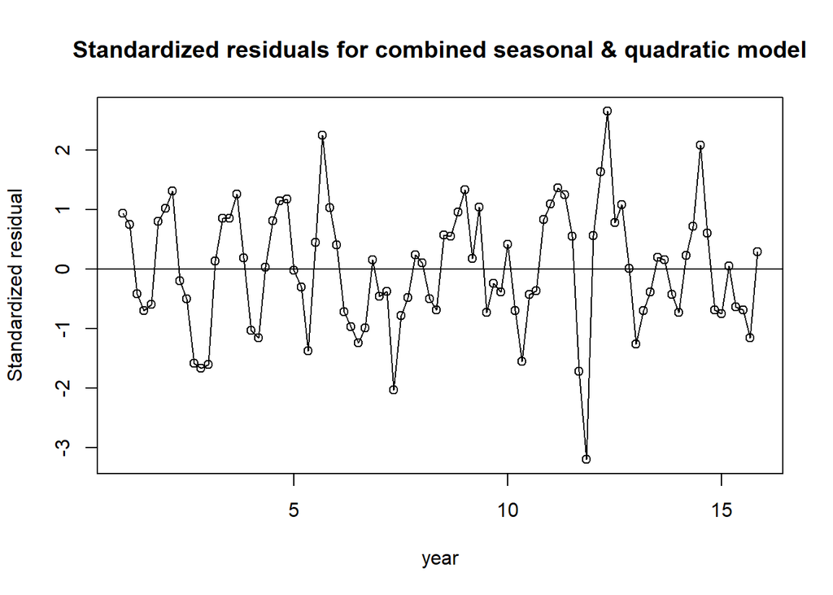

```r
plot(res.cosine_model, x=as.vector(time(seasonal_data)), type="o", xlab="year", ylab="Standardized residual", main="Standardized residuals for combined seasonal & quadratic model")
abline(h=0)
```

### 4.11b Histogram

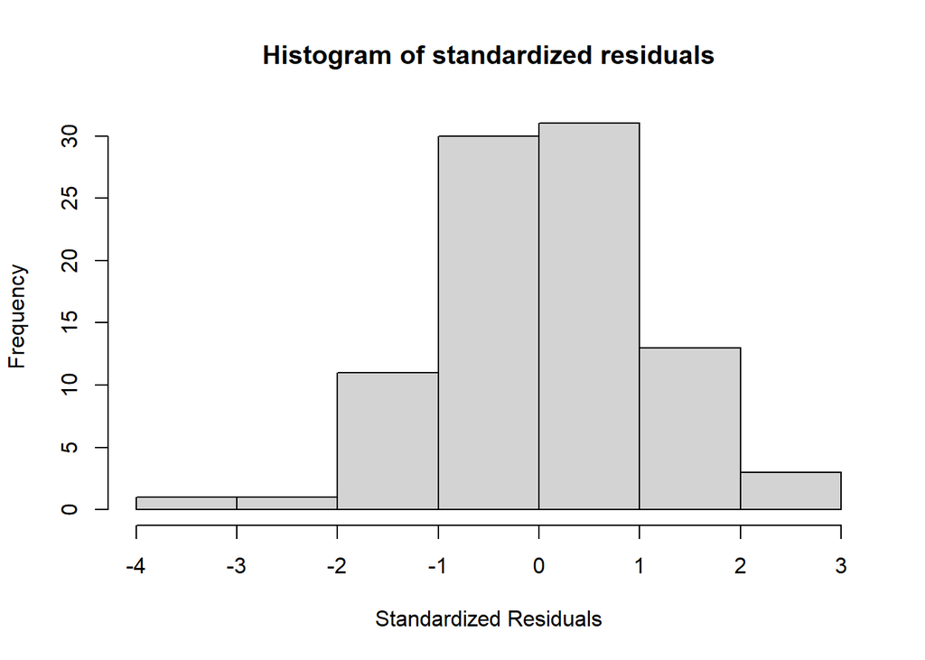

```r
hist(res.cosine_model, main="Histogram of standardized residuals", xlab="Standardized Residuals")
```

The histogram of the cosine model looks normal.

### 4.11c Q-Q Plot

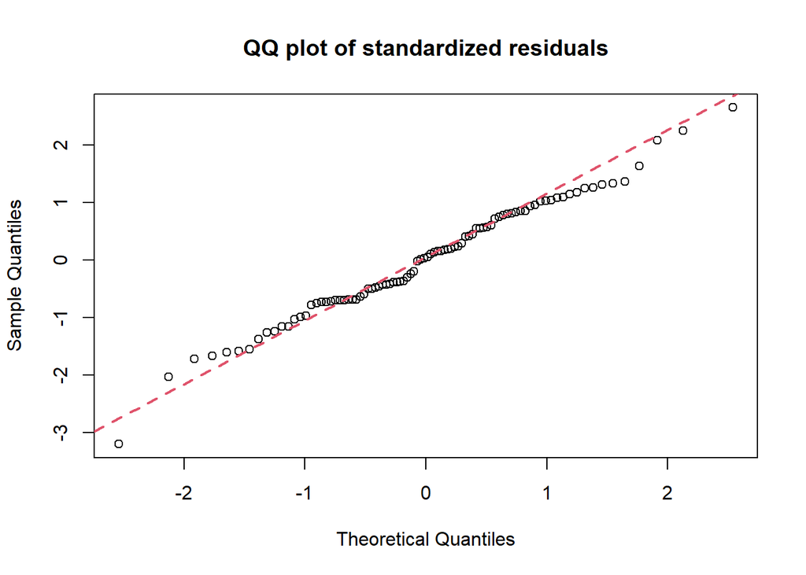

```r
qqnorm(res.cosine_model, main="QQ plot of standardized residuals")
qqline(res.cosine_model, col=2, lty=2, lwd=2)
```

The points in the qqplot shows signs of normal distribution as well.

### 4.11d Shapiro-Wilks Normality Test

```r
shapiro.test(res.cosine_model)
```

```
##
##  Shapiro-Wilk normality test
##
## data:  res.cosine_model
## W = 0.9885, p-value = 0.6206
```

Shapiro-wilk normality test gives a p-value of 0.6205, the null hypothesis that the stochastic component of the cosine model is not rejected.

### 4.11e ACF and PACF of standardized residuals

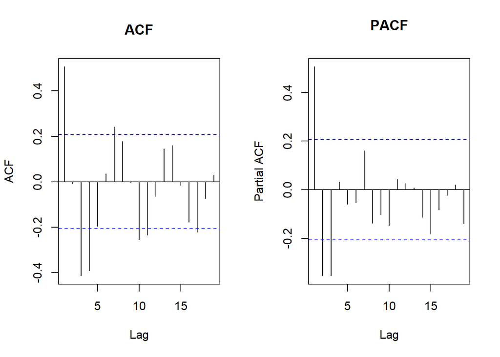

```r
par(mfrow=c(1,2))
acf(res.cosine_model, main="ACF")
pacf(res.cosine_model, main="PACF")
```

## 4.12 Best Model

```r
AIC(linear_model,quadratic_model, seasonal_model, seasonal_quad_model, cosine_model)
```

```
##                     df      AIC
## linear_model         3 387.0237
## quadratic_model      4 367.6643
## seasonal_model       7 494.2110
## seasonal_quad_model  9 375.6332
## cosine_model         6 370.0431
```

```r
BIC(linear_model,quadratic_model, seasonal_model, seasonal_quad_model, cosine_model)
```

```
##                     df      BIC
## linear_model         3 394.5231
## quadratic_model      4 377.6635
## seasonal_model       7 511.7097
## seasonal_quad_model  9 398.1314
## cosine_model         6 385.0420
```

Both AIC and BIC supports the quadratic model where that model has the lowest AIC and BIC score.

Quadratic trend model has the second highest adjusted R-squared with only the combined seasonal and quadratic model having a higher adjusted R-squared. However, the coefficients for the quadratic model were are statistically significant and the model was able to reduce the stationarity and the possess residuals that were normal.

# 5. Forecasting

The ozone time series will be forecasted for 5 years from 2017 to 2021 using the quadratic model and a new data frame.

```r
t <- seq(2017, 2021,1)
t2 <- t^2
ozone_forecast_df <- data.frame(t, t2)
forecast_model <- predict(quadratic_model, newdata = ozone_forecast_df, interval = "prediction")
print(forecast_model)
```

```
##         fit       lwr       upr
## 1 -10.34387 -14.13556 -6.552180
## 2 -10.59469 -14.40282 -6.786548
## 3 -10.84856 -14.67434 -7.022786
## 4 -11.10550 -14.95015 -7.260851
## 5 -11.36550 -15.23030 -7.500701
```

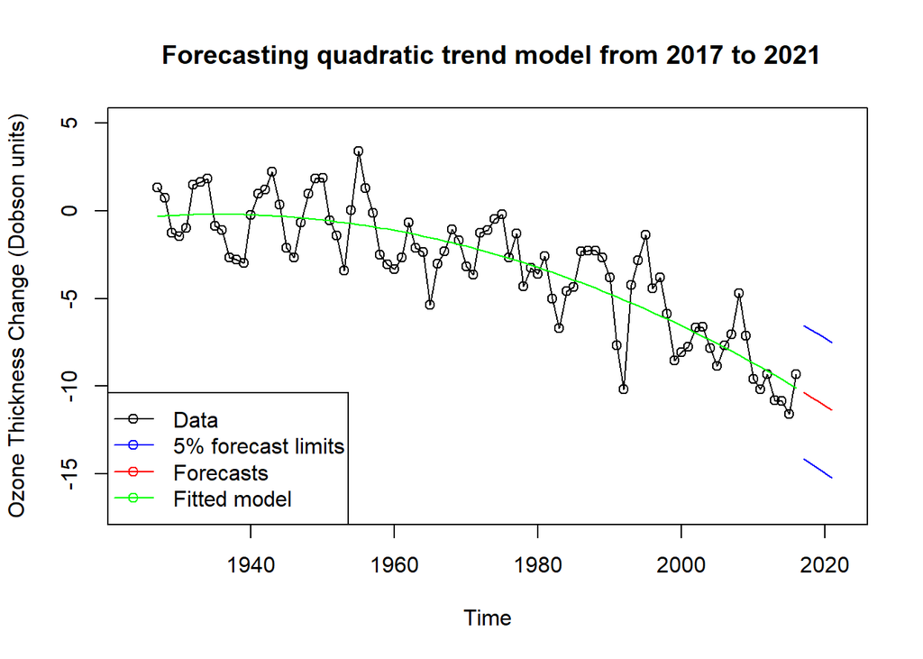

```r
plot(ozone, xlim = c(1924,2022), ylim = c(-17, 5), type="o", ylab='Ozone Thickness Change (Dobson units)',
     main = " Forecasting quadratic trend model from 2017 to 2021")
lines(ts(as.vector(forecast_model [,1]), start = c(2017,1), frequency = 1), col="red", type="l")
lines(ts(as.vector(forecast_model [,2]), start = c(2017,1), frequency = 1), col="blue", type="l")
lines(ts(as.vector(forecast_model [,3]), start = c(2017,1), frequency = 1), col="blue", type="l")
lines(ts(fitted(quadratic_model), start=c(1927,1), frequency=1), col="green", type="l")
legend("bottomleft", lty=1, pch=1, col=c("black","blue","red","green"), text.width = 23,
       c("Data","5% forecast limits", "Forecasts","Fitted model"))
```

The blue lines representing the prediction interval such that 95% of the prediction of the change in ozone thickness will be within those two blue lines.

# 6. Analysis of proposed ARIMA(p,d,q) model

The ozone time series has a downward trend with some evidence of seasonality, changing variations with both moving average and autoregressive behavior are present but without any intervention point.

Next, a set of possible ARIMA(p,d,q) models will be proposed using model specification tools. Before doing that, transformation like Box-cox, logaritham and differencing will be used to deal with the non-stationarity of the series.

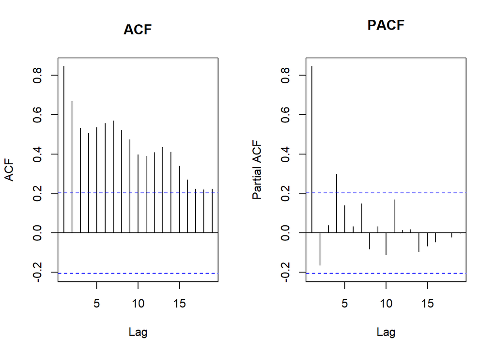

```r
par(mfrow=c(1,2))
acf(ozone, main='ACF')
pacf(ozone, main='PACF')
```

In the ACF plot, there is slow decaying pattern with signs of seasonality. For the PACF plot, the first lag has a very high correlation implying the existence of a trend and non-stationarity.

To deal with non-stationarity, there are several transformation to remove variance in the data such as Box-Cox and Natural Logarithm transformation.

## 6.1 Dickey-Fuller Unit-Root Test (ADF) for Ozone time series

```r
adf.test(ozone)
```

```
##
##  Augmented Dickey-Fuller Test
##
## data:  ozone
## Dickey-Fuller = -3.2376, Lag order = 4, p-value = 0.0867
## alternative hypothesis: stationary
```

To confirm the non-stationarity, the unit root test is used. The p-value for the unit-root test is 0.0867, which is greater than 0.05 significance level. Therefore null hypothsis of non-stationarity is not rejected.

Next, the Box-Cox and Natural Logarithm transformation will be used improve the normality of the ozone time series.

## 6.2 Box-Cox transformation

```r
ozone.positive_data <- ozone + abs(min(ozone))+1
ozone.bc <- BoxCox.ar(ozone.positive_data)
```

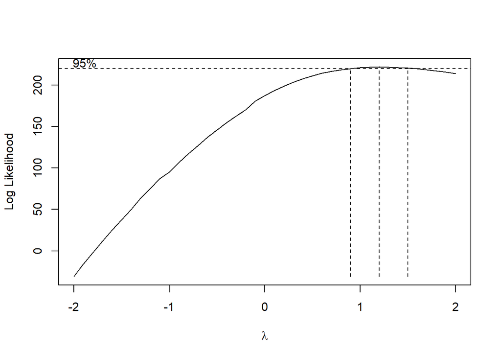

```r
ozone.bc$ci # values of first and third lines
```

```
## [1] 0.9 1.5
```

```r
mean(ozone.bc$ci)
```

```
## [1] 1.2
```

```r
lambda <- mean(ozone.bc$ci)
lambda
```

```
## [1] 1.2
```

```r
ozone.bc1 <- ((ozone.positive_data^lambda)-1) / lambda
```

The lambda value is 1.2 which is very high indicating that the Box Cox transformation will likely not be useful in stabilizing the variance.

### 6.2a Plot of Box-Cox transformed data

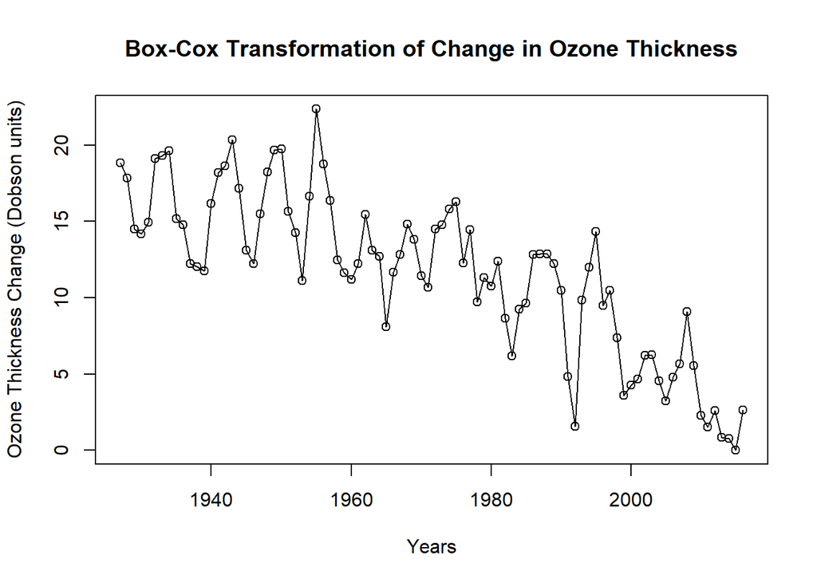

```r
plot(ozone.bc1, type="o", xlab="Years", main="Box-Cox Transformation of Change in Ozone Thickness", ylab="Ozone Thickness Change (Dobson units)")
```

The plot is almost identical to the original plot with a downward trend and variation has not changed.

### 6.2b Q-Q Plot for Box-Cox transformed data

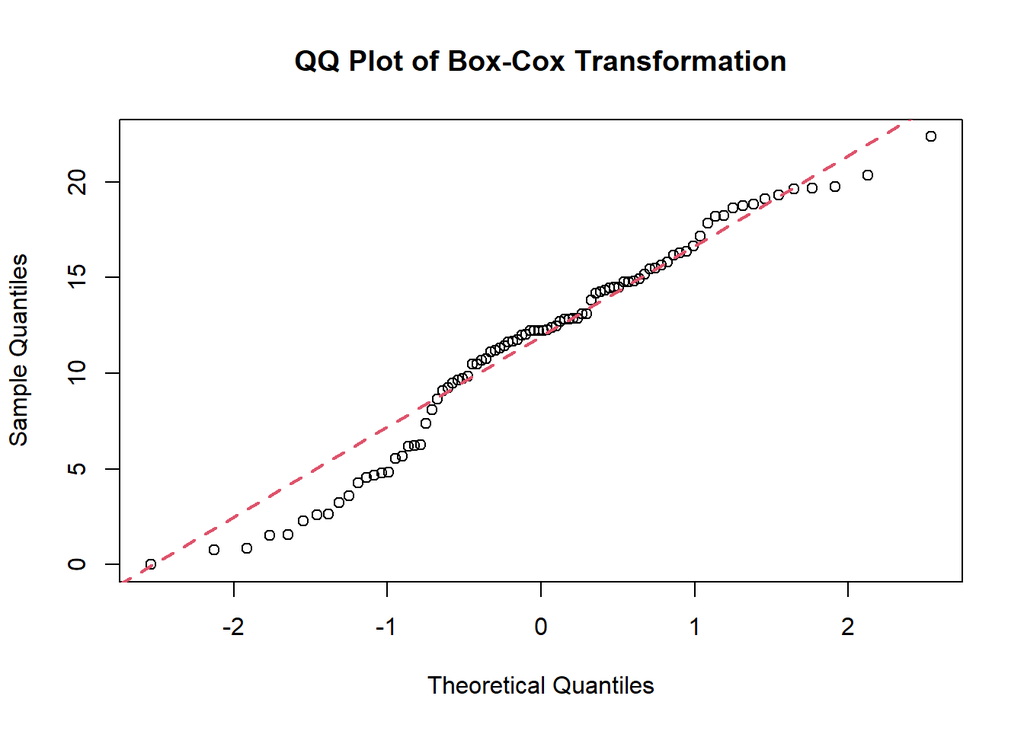

```r
qqnorm(ozone.bc1, main="QQ Plot of Box-Cox Transformation")
qqline(ozone.bc1, col=2, lty=2, lwd=2)
```

In the QQ plot the tails of the distribution is far from the normality.

### 6.2c Dickey-Fuller Unit Root test

```r
adf.test(ozone.bc1)
```

```
##
##  Augmented Dickey-Fuller Test
##
## data:  ozone.bc1
## Dickey-Fuller = -3.3923, Lag order = 4, p-value = 0.06129
## alternative hypothesis: stationary
```

The unit root test p-value is 0.06129, and the null hypothesis of non-stationarity is not rejected. Therefore, the Box-cox transformation does not transform the time series to stationarity.

### 6.2d Shapiro Test for Box-Cox transformed data

```r
shapiro.test(ozone.bc1)
```

```
##
##  Shapiro-Wilk normality test
##
## data:  ozone.bc1
## W = 0.96644, p-value = 0.01995
```

The p-value of the Shapiro-Wilk normality test is 0.01995 and the null hypothesis of normal distribution will be rejected.

By examining the results from the QQ plot and Shapiro Test, it shows that the Box-Cox transformation was unsuccessful in transforming the ozone time series to improve the normality of the observations.

The next method to explore is the natural logaritham transformation.

## 6.3 Logarithm Transformation

```r
ozone_log <- log(ozone.positive_data)
```

### 6.3a Plot of Logaritham Transformation data

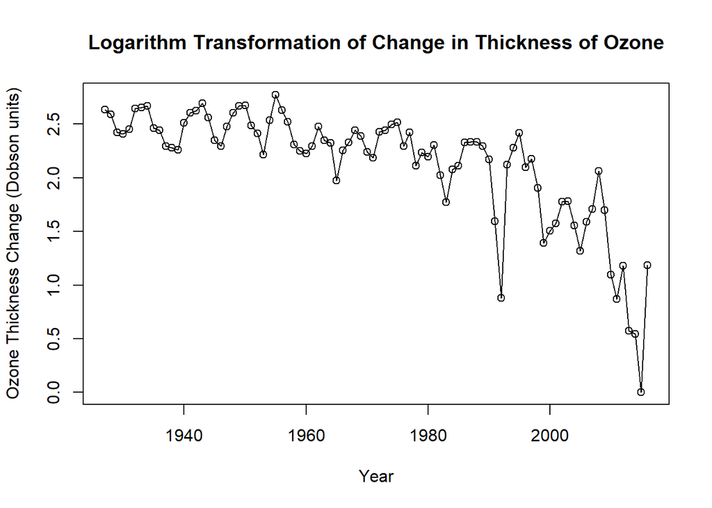

```r
plot(ozone_log, type="o", xlab="Year", main="Logarithm Transformation of Change in Thickness of Ozone", ylab="Ozone Thickness Change (Dobson units)")
```

Similar to Box-Cox transformation, there is still a downward trend in the data and log transformation did not significantly improve the normality of the ozone time series.

### 6.3b Q-Q Plot for Logaritham transformed data

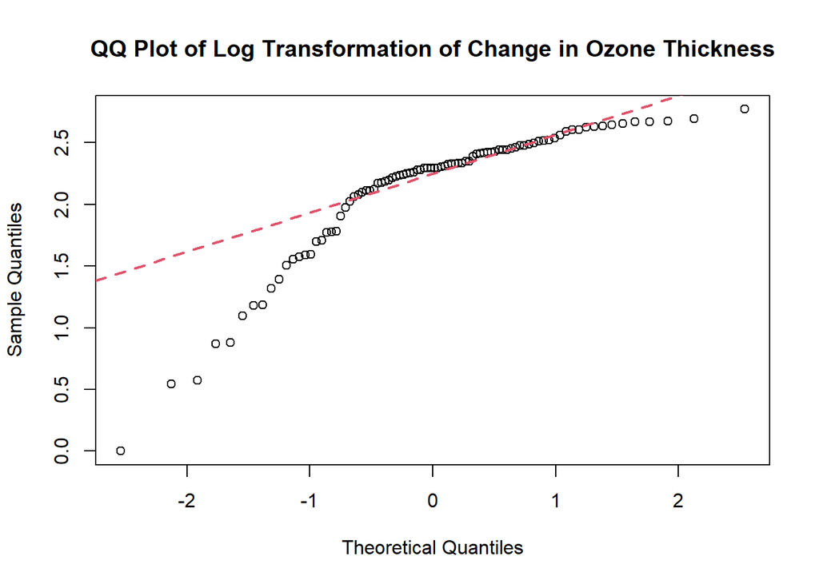

```r
qqnorm(ozone_log, main="QQ Plot of Log Transformation of Change in Ozone Thickness")
qqline(ozone_log, col=2, lty=2, lwd=2)
```

From the QQ plot, it can be observed that the front tails are very far off the red line indicating that they are far from normality and the logaritham transformation has not significantly improve the normality of the time series.

### 6.3c Dickey-Fuller Unit Root test

```r
adf.test(ozone_log)
```

```
##
##  Augmented Dickey-Fuller Test
##
## data:  ozone_log
## Dickey-Fuller = -2.3196, Lag order = 4, p-value = 0.4446
## alternative hypothesis: stationary
```

The unit root test p-value is 0.4446, and the null hypothesis of non-stationarity is not rejected. Therefore, the log transformation does not transform the time series to stationarity.

### 6.3d Shapiro Test for Logaritham Transformed Data

```r
shapiro.test(ozone_log)
```

```
##
##  Shapiro-Wilk normality test
##
## data:  ozone_log
## W = 0.81905, p-value = 3.949e-09
```

The p-value of the Shapiro-Wilk normality test is 3.949e-09, and the null hypothesis of normal distribution will be rejected. Therefore the log transformed data has weak evidence of normality.